# Report exercise 8: Stepwise regression

Janina Hämmerli

2023-04-23

## Loading the data

First, i loaded the half-hourly fluxes dataset into my file.

```r
half_hourly_fluxes <- readr::read_csv("~/Studium Jahr 2/ADGS/my_project/agds_report_janinahaemmerli/Data/df_for_stepwise_regression.csv")
```

## Exploring the data

To get an overview of the data, I used the summary function, which helped me to take a look at the structure of the data and the different variables. Something I observed is, that some variables have a lot of NA values, especially the variable LW_IN_F_MDS, where almost half of the observations are a NA value. I asked myself how the NA values would influence the outcome of the stepwise forward regression and if the predictors with many or few/none NA values would fit better into the model.

```r
summary(half_hourly_fluxes)
```

```
##     siteid            TIMESTAMP               TA_F            SW_IN_F
##  Length:23011       Min.   :1996-01-01   Min.   :-29.184   Min.   :  0.156
##  Class :character   1st Qu.:2002-12-01   1st Qu.:  0.431   1st Qu.: 52.933
##  Mode  :character   Median :2007-02-15   Median :  7.286   Median :120.679
##                     Mean   :2006-10-25   Mean   :  6.950   Mean   :137.633
##                     3rd Qu.:2011-01-23   3rd Qu.: 13.313   3rd Qu.:215.243
##                     Max.   :2014-12-31   Max.   : 31.166   Max.   :398.192
##
##     LW_IN_F          VPD_F             PA_F             P_F
##  Min.   :138.1   Min.   : 0.000   Min.   : 80.37   Min.   :  0.000
##  1st Qu.:265.0   1st Qu.: 0.831   1st Qu.: 84.31   1st Qu.:  0.000
##  Median :300.1   Median : 2.542   Median : 97.38   Median :  0.010
##  Mean   :295.8   Mean   : 3.787   Mean   : 93.47   Mean   :  2.320
##  3rd Qu.:328.9   3rd Qu.: 5.239   3rd Qu.: 98.77   3rd Qu.:  1.749
##  Max.   :420.1   Max.   :33.290   Max.   :103.28   Max.   :186.400
##
##       WS_F          TA_F_MDS        SW_IN_F_MDS       LW_IN_F_MDS
##  Min.   :0.106   Min.   :-29.184   Min.   :  0.156   Min.   :138.1
##  1st Qu.:1.805   1st Qu.:  0.446   1st Qu.: 53.317   1st Qu.:269.5
##  Median :2.387   Median :  7.356   Median :120.031   Median :303.3
##  Mean   :2.670   Mean   :  6.987   Mean   :137.482   Mean   :299.4
##  3rd Qu.:3.286   3rd Qu.: 13.301   3rd Qu.:215.580   3rd Qu.:332.9
##  Max.   :9.928   Max.   : 31.166   Max.   :398.192   Max.   :420.1
##                  NA's   :325       NA's   :341       NA's   :11057
##    VPD_F_MDS        CO2_F_MDS        PPFD_IN        GPP_NT_VUT_REF
##  Min.   : 0.000   Min.   :297.3   Min.   : -0.249   Min.   :-6.683
##  1st Qu.: 0.852   1st Qu.:372.1   1st Qu.: 91.040   1st Qu.: 0.802
##  Median : 2.612   Median :383.7   Median :231.956   Median : 2.845
##  Mean   : 3.850   Mean   :385.1   Mean   :271.714   Mean   : 3.503
##  3rd Qu.: 5.326   3rd Qu.:395.6   3rd Qu.:430.028   3rd Qu.: 5.600
##  Max.   :33.290   Max.   :724.2   Max.   :995.106   Max.   :18.511
##  NA's   :768      NA's   :290     NA's   :4574      NA's   :2426
##      USTAR
##  Min.   :0.0749
##  1st Qu.:0.2850
##  Median :0.3856
##  Mean   :0.4255
##  3rd Qu.:0.5244
##  Max.   :1.5941
##  NA's   :2468
```

As a next step I decided which variables I wanted to incorporate into the regression. I couldn’t find out what the USTAR variable was about, so I decided to leave it out. Then I made a dataset with only the predictors I was going to use in the regression and the GPP. This dataset I’m using later on in my stepwise forward regression

```r
half_hourly_fluxes_sub <- half_hourly_fluxes[,3:16]
```

## Step 1-3 stepwise forward regression:

To begin with I made a simple for loop that creates a table with the R square values, to which I added the name of the predictor in an additional column. Then I selected the highest R square value, which belonged to the predictor PPFD_IN, and computed its AIC. Here I could see that a predictor with many NA values reached the highest R squared and I asked myself if this had something to do with the fact that this variable has less observation that influenced the model.

```r
df_rsq <- data.frame(r_squared = numeric()) #creating an empty data frame

for (i in half_hourly_fluxes[3:15]){
  mod <- lm(GPP_NT_VUT_REF ~ i, data = half_hourly_fluxes)
  r_squared <- summary(mod)$r.squared
  df_rsq[nrow(df_rsq) + 1,] <- r_squared #adding the R2 values to the data frame
}
names <- data.frame(predictors = colnames(half_hourly_fluxes)[3:15]) #creating a data frame with the predictor names
df_rsq <- cbind(names, df_rsq) #joining the R2 values and the corresponding predictor names
max(df_rsq[,2])
```

```
## [1] 0.4520702
```

```r
best_mod <- lm(GPP_NT_VUT_REF ~ PPFD_IN, data = half_hourly_fluxes)
extractAIC(best_mod)[2]
```

```
## [1] 29689.54
```

To take a look at the model, I made a scatterplot where I can see how the variables co-vary. From the plot I observed that there is a positive linear relationship between the variables, but as the dots aren’t arranged in an even line, the relationship could be better, so this model doesn’t fit the data perfectly.

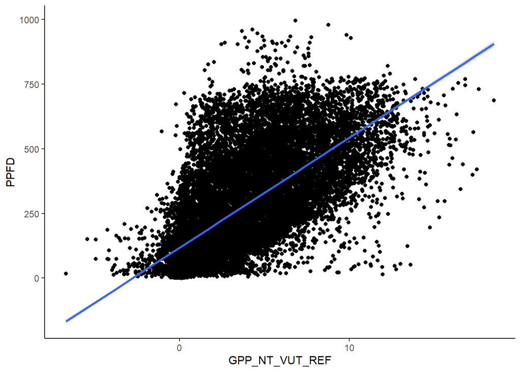

```r
library(ggplot2)

ggplot(data = half_hourly_fluxes) +
  geom_point(aes(
    x = GPP_NT_VUT_REF,
    y = PPFD_IN)) +
  labs(x = "GPP_NT_VUT_REF",
       y= "PPFD") +
  geom_smooth(aes(
    x=GPP_NT_VUT_REF,
    y=PPFD_IN),
    method = "lm") +
  theme_classic()
```

## Stepwise forward regression

Before I started with writing my own loop of a stepwise forward regression, I wrote down some ideas down what the implementation should contain. My ideas where:

1. Creating a for loop that gives me a table with all the R squared values.
2. Find out the highest R squared value from the table and save the index to find the corresponding predictor in the data frame with all the variables used.
3. Calculate the AIC of the new best model and compare it with the AIC of the best old model. If the AIC of the new model is bigger than the AIC of the old model, the loop has to stop (implement a if or while loop).
4. If the loop goes on, the newly added predictor has to be removed from the remaining variables that aren’t in the model yet and added to the already selected variables.
5. A new run of the loop can start

The loop that I came up with doesn’t work properly. I unfortunately couldn’t let it run entirely because of multiple errors that I wasn’t able to solve. But when I did run the different steps of the code separately, it seemed to work, so the problem could be something that occurs when running it all at once.

```r
# defining some variables used in the loop
best_p2 <- NULL
var_remaining <- half_hourly_fluxes_sub[,-14] #df with all the predictors
var_selected <- data.frame(GPP = half_hourly_fluxes$GPP_NT_VUT_REF)
df_rsq2 <- data.frame(r_squared = numeric()) #df where the R squared gets stored
AIC_old <- 60000 # random number to start that is higher than AIC_new
AIC_new <- 50000

while (AIC_old > AIC_new){
   for (i in var_remaining){
      mod2 <- lm(GPP ~ . + i, data = var_selected) # I'm not quite sure if the lm(GPP ~ . + i, data = var_selected) statement   really works, because I don't know if the different predictors get separated with a "+" like this
      r_squared2 <- summary(mod3)$r.squared
      df_rsq2[nrow(df_rsq2) + 1,] <- r_squared2
    }
  best_p2 <- which.max(unlist(df_rsq2)) #saving index of best fitting predictor
  var_selected[,ncol(var_selected) + 1] <- var_remaining[,best_p2]

  AIC_old <- AIC_new
  AIC_new <- extractAIC(lm(GPP ~ . + unlist(var_remaining[,best_p2]), data = var_selected))[2]

  var_remaining <- var_remaining[-which(names(var_remaining)==names(var_selected))] #deleting selected predictor from df
}
```

```
## Error in summary(mod3): Objekt 'mod3' nicht gefunden
```